# Lecture 2.1 in-class code and follow-up

Andy Eggers

10/5/2021

We used this code in class to show code completion:

```r
dat <- read_csv(file = "./../data/vdem_2010_extract.csv")
dat %>%
  select(country_name, continent_name)
```

```
## # A tibble: 181 x 2
##    country_name  continent_name
##    <chr>         <chr>
##  1 Mexico        North America
##  2 Suriname      South America
##  3 Sweden        Europe
##  4 Switzerland   Europe
##  5 Ghana         Africa
##  6 South Africa  Africa
##  7 Japan         Asia
##  8 Burma/Myanmar Asia
##  9 Russia        Europe
## 10 Russia        Asia
## # … with 171 more rows
```

## Recoding variables

I wrote on the board how to use `case_when` to create a new variable on the basis of one or more existing variables.

First we show the varaible we want to recode:

```r
vd <- vdemdata::vdem

vd %>%
  count(e_regionpol_6C)
```

```
##   e_regionpol_6C    n
## 1              1 2553
## 2              2 4769
## 3              3 3266
## 4              4 6044
## 5              5 6185
## 6              6 4375
```

Now we create a new variable to replace the numerical regions with text strings:

```r
vd %>%
  mutate(region = case_when(
    e_regionpol_6C == 1 ~ "E. Europe & Central Asia",
    e_regionpol_6C == 2 ~ "Latin America & Caribbean",
    e_regionpol_6C == 3 ~ "Middle East & N. Africa",
    e_regionpol_6C == 4 ~ "Sub-Saharan Africa",
    e_regionpol_6C == 5 ~ "W. Europe & N. America",
    e_regionpol_6C == 6 ~ "Asia & Pacific")) %>%
  count(region)
```

```
##                      region    n
## 1            Asia & Pacific 4375
## 2  E. Europe & Central Asia 2553
## 3 Latin America & Caribbean 4769
## 4   Middle East & N. Africa 3266
## 5        Sub-Saharan Africa 6044
## 6    W. Europe & N. America 6185
```

Another option suggested in class is `recode`. (I said I don’t use this but I realized later that I actually do!)

```r
# demonstrating recode for recoding
vd1 <- vd %>%
  mutate(region = recode(e_regionpol_6C,
                         `1` = "E. Europe & Central Asia",
                         `2` = "Latin America & Caribbean",
                         `3` = "Middle East & N. Africa",
                         `4` = "Sub-Saharan Africa",
                         `5` = "W. Europe & N. America",
                         `6` = "Asia & Pacific"))

vd1 %>%
  count(region)
```

```
##                      region    n
## 1            Asia & Pacific 4375
## 2  E. Europe & Central Asia 2553
## 3 Latin America & Caribbean 4769
## 4   Middle East & N. Africa 3266
## 5        Sub-Saharan Africa 6044
## 6    W. Europe & N. America 6185
```

We stored the result of that recode in `vd1` so now we can use it to reproduce the plot we made in class.

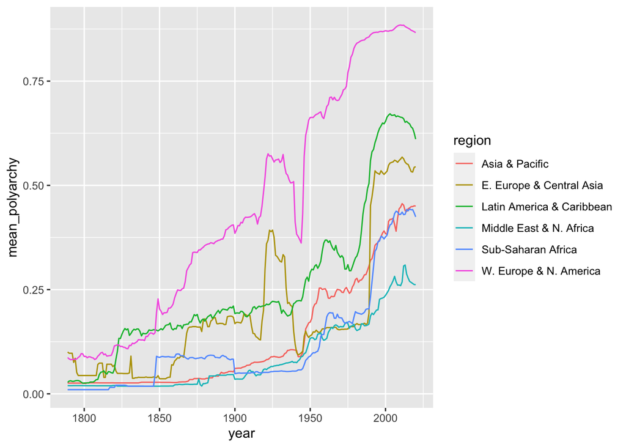

```r
# plotting year-region average polyarchy over time
vd1 %>%
  group_by(year, region) %>%
  summarize(mean_polyarchy = mean(v2x_polyarchy, na.rm = T)) %>%
  ggplot(aes(x = year, y = mean_polyarchy, col = region)) +
  geom_line()
```

At the end of lecture I showed how you can get something similar using `geom_smooth()`. You can get closer if you specify method `loess` and reduce the default `span` argument. (I also drop the confidence intervals using `se = F` and make the lines thinner to match the default for `geom_line()`.) It’s a little bit smoother than just the grouped means, but if I make the span smaller I get an error.

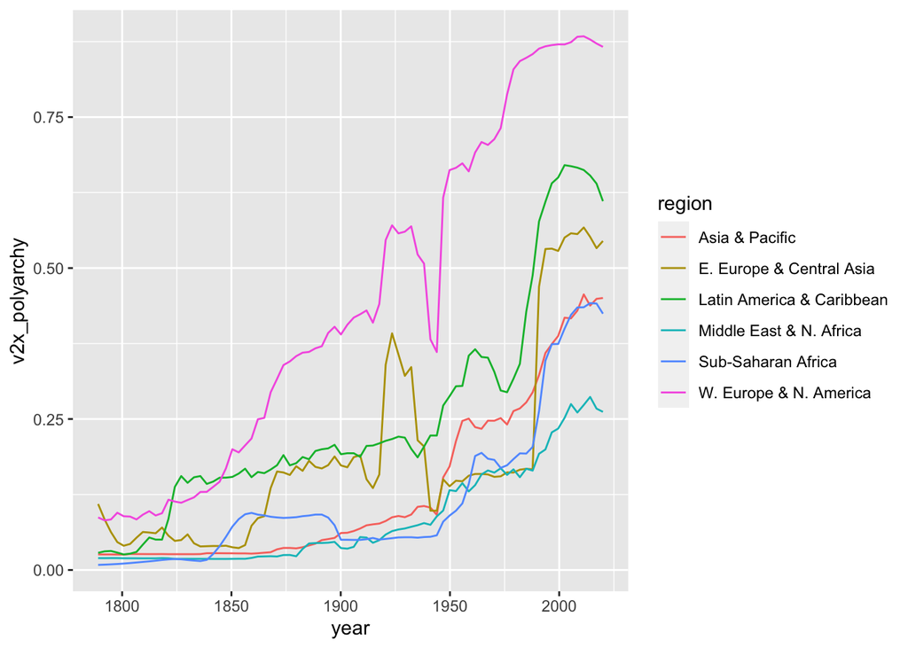

```r
# demonstrating using geom_smooth to get something very close to group means
vd1 %>%
  ggplot(aes(x = year, y = v2x_polyarchy, col = region)) +
  geom_smooth(method = "loess", span = .02, se = F, lwd = .5)
```

```r
# by trial and error I set the span as small as I could.
```